# IBM6300-Shopify Store - Assignment 1

Author

Wenting Jiang

Published

June 24, 2026

# 1 Evidence of Shopify Learning Completion

The following screenshot shows completion of the required Shopify Academy learning modules.

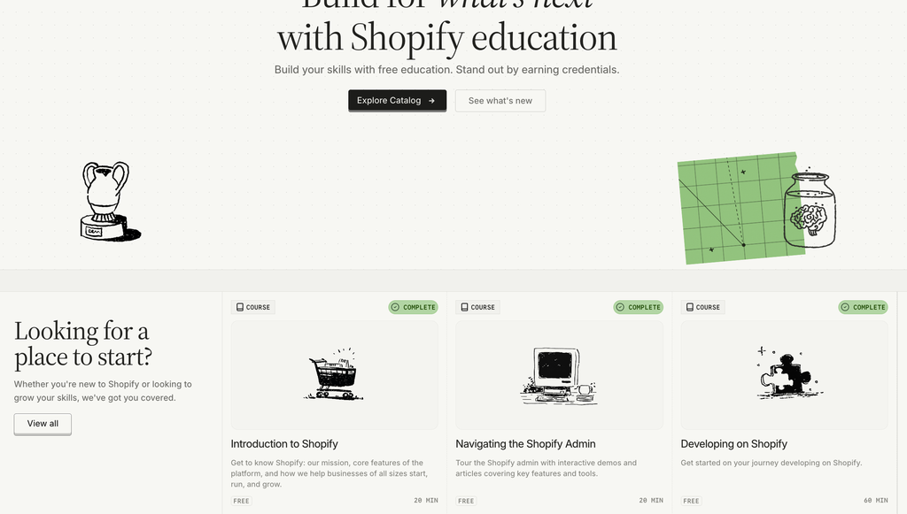

Shopify Learning Completion

# 2 Shopify Admin Exploration Screenshot

The following screenshot shows access to the Shopify Admin dashboard.

[figure not shown]

Shopify Admin Dashboard

# 3 Feature Reflection

## 3.1 Product Management

Shopify allows businesses to add, edit, and organize products. Store owners can manage inventory, pricing, and product information in one place.

## 3.2 Customer Management

Shopify stores customer information and purchase history. This helps businesses better understand customer behavior and improve customer relationships.

## 3.3 Analytics

Shopify provides analytics tools that track sales, website traffic, and customer activity. These reports help businesses make informed decisions.

## 3.4 Discounts and Promotions

Shopify allows businesses to create discount codes and promotional campaigns. These tools can encourage repeat purchases and attract new customers.

## 3.5 Online Store Themes

Shopify provides customizable themes that allow businesses to create professional online stores without advanced coding skills.

# 4 CPP Farm Store Application Reflection

Shopify could help CPP Farm Store expand its online presence and reach more customers beyond the local area. The platform would allow the Farm Store to sell specialty products, gift baskets, preserves, sauces, and seasonal products online. Shopify’s analytics and customer management tools could help the store better understand customer preferences and improve marketing efforts. Shopify could also support loyalty programs, promotions, and online ordering, helping the Farm Store increase sales while maintaining its farm-to-community identity.

# 5 Appendix

GitHub Repository: https://github.com/WentingJiang00/Shopify-assign1

GitHub Pages: https://wentingjiang00.github.io/Shopify-assign1/